# Project 1: Typhoons

Gus Coffey and Kelli McCarty

Spring 2026

# Set Up

## Loading Libraries

```r
library(tidyverse)
```

## Loading Data

```r
atlantic <- "atlantic.csv"
raw_atlantic <- read_csv(atlantic)

pacific <- "pacific.csv"
raw_pacific <- read_csv(pacific)
```

### Data Description

Link: https://www.kaggle.com/datasets/noaa/hurricane-database?resource=download&select=atlantic.csv

This dataset contains historical records of tropical cyclones in the Atlantic and Pacific Oceans from the National Hurricane Center (NHC). It includes the date, location, wind speed, minimum pressure, and status of a storm event.

# Data Cleaning and Wrangling

### Combining our datasets

```r
# Adding new column that labels all observations as coming from the Atlantic ocean
raw_atlantic <- raw_atlantic %>% mutate(ocean = "ATL")

# Adding new column that labels all observations as coming from the Pacific ocean
raw_pacific <- raw_pacific %>% mutate(ocean = "PAC")

# Combining pacific and atlantic data into one dataframe
raw_pac_atl <- rbind(raw_pacific, raw_atlantic)

str(raw_pac_atl)
```

```
## tibble [75,242 × 23] (S3: tbl_df/tbl/data.frame)
##  $ ID              : chr [1:75242] "EP011949" "EP011949" "EP011949" "EP011949" ...
##  $ Name            : chr [1:75242] "UNNAMED" "UNNAMED" "UNNAMED" "UNNAMED" ...
##  $ Date            : num [1:75242] 19490611 19490611 19490611 19490611 19490612 ...
##  $ Time            : num [1:75242] 0 600 1200 1800 0 600 1200 1200 1800 0 ...
##  $ Event           : chr [1:75242] NA NA NA NA ...
##  $ Status          : chr [1:75242] "TS" "TS" "TS" "TS" ...
##  $ Latitude        : chr [1:75242] "20.2N" "20.2N" "20.2N" "20.3N" ...
##  $ Longitude       : chr [1:75242] "106.3W" "106.4W" "106.7W" "107.7W" ...
##  $ Maximum Wind    : num [1:75242] 45 45 45 45 45 45 45 45 45 45 ...
##  $ Minimum Pressure: num [1:75242] -999 -999 -999 -999 -999 -999 -999 -999 -999 -999 ...
##  $ Low Wind NE     : num [1:75242] -999 -999 -999 -999 -999 -999 -999 -999 -999 -999 ...
##  $ Low Wind SE     : num [1:75242] -999 -999 -999 -999 -999 -999 -999 -999 -999 -999 ...
##  $ Low Wind SW     : num [1:75242] -999 -999 -999 -999 -999 -999 -999 -999 -999 -999 ...
##  $ Low Wind NW     : num [1:75242] -999 -999 -999 -999 -999 -999 -999 -999 -999 -999 ...
##  $ Moderate Wind NE: num [1:75242] -999 -999 -999 -999 -999 -999 -999 -999 -999 -999 ...
##  $ Moderate Wind SE: num [1:75242] -999 -999 -999 -999 -999 -999 -999 -999 -999 -999 ...
##  $ Moderate Wind SW: num [1:75242] -999 -999 -999 -999 -999 -999 -999 -999 -999 -999 ...
##  $ Moderate Wind NW: num [1:75242] -999 -999 -999 -999 -999 -999 -999 -999 -999 -999 ...
##  $ High Wind NE    : num [1:75242] -999 -999 -999 -999 -999 -999 -999 -999 -999 -999 ...
##  $ High Wind SE    : num [1:75242] -999 -999 -999 -999 -999 -999 -999 -999 -999 -999 ...
##  $ High Wind SW    : num [1:75242] -999 -999 -999 -999 -999 -999 -999 -999 -999 -999 ...
##  $ High Wind NW    : num [1:75242] -999 -999 -999 -999 -999 -999 -999 -999 -999 -999 ...
##  $ ocean           : chr [1:75242] "PAC" "PAC" "PAC" "PAC" ...
```

### Cleaning our combined dataset

```r
# Changing Date column datatype from numeric to date (yyyy-mm-dd)
raw_pac_atl$Date <- as.Date(as.character(raw_pac_atl$Date), format = "%Y%m%d")

# Renaming columns to remove spaces for easier use
storms <- raw_pac_atl %>% select(-Event) %>%
  rename(MaxWind = `Maximum Wind`,
  MinPress = `Minimum Pressure`,
  LowWindNE = `Low Wind NE`,
  LowWindSE = `Low Wind SE`,
  LowWindSW = `Low Wind SW`,
  LowWindNW = `Low Wind NW`,
  ModWindNE = `Moderate Wind NE`,
  ModWindSE = `Moderate Wind SE`,
  ModWindSW = `Moderate Wind SW`,
  ModWindNW = `Moderate Wind NW`,
  HiWindNE = `High Wind NE`,
  HiWindSE = `High Wind SE`,
  HiWindSW = `High Wind SW`,
  HiWindNW = `High Wind NW`)

storms <- storms %>%
  # Removing all observations with -999 in any of the following columns
  # -999 is a place holder for variables that were not measured
  filter(!if_any(c(MaxWind, MinPress,
                   LowWindNE, LowWindSE,
                   LowWindSW, LowWindNW,
                   ModWindNE, ModWindSE,
                   ModWindSW, ModWindNW,
                   HiWindNE, HiWindSE,
                   HiWindSW, HiWindNW), ~ . == -999)) %>%
  mutate(
    # Creating new lat and lon columns with positive and negative
    # degrees instead of N, E, S, W
    lat = as.numeric(str_remove(Latitude, "[NS]")) *
          ifelse(str_detect(Latitude, "S"), -1, 1),
    lon = as.numeric(str_remove(Longitude, "[EW]")) *
          ifelse(str_detect(Longitude, "W"), -1, 1),
    # Breaking status codes into 5 categories for simplicity
    status_group = case_when(
      Status %in% c("TD", "TS", "HU") ~ "tropical",
      Status %in% c("SD", "SS")       ~ "subtropical",
      Status == "EX"                  ~ "extratropical",
      Status %in% c("LO", "DB", "WV") ~ "low-pressure",
      TRUE                            ~ "other"
    ),
    # Turning the status_group column into a factor
    status_group = factor(status_group,
                          levels = c("tropical",
                                     "subtropical",
                                     "extratropical",
                                     "low-pressure",
                                     "other")
                          )
    )
```

# Distributions and Summary Statistics

## Summary Statistics

```r
# Show first 6 rows of data
head(storms)
```

| ID | Name | Date | Time | Status | Latitude | Longitude | MaxWind | MinPress | LowWindNE | LowWindSE | LowWindSW | LowWindNW | ModWindNE | ModWindSE | ModWindSW | ModWindNW | HiWindNE | HiWindSE | HiWindSW | HiWindNW | ocean | lat | lon | status_group |
| --- | --- | --- | --- | --- | --- | --- | --- | --- | --- | --- | --- | --- | --- | --- | --- | --- | --- | --- | --- | --- | --- | --- | --- | --- |
| EP012004 | AGATHA | 2004-05-22 | 0 | TD | 14.7N | 107.6W | 25 | 1006 | 0 | 0 | 0 | 0 | 0 | 0 | 0 | 0 | 0 | 0 | 0 | 0 | PAC | 14.7 | -107.6 | tropical |
| EP012004 | AGATHA | 2004-05-22 | 600 | TD | 15.4N | 108.5W | 30 | 1006 | 0 | 0 | 0 | 0 | 0 | 0 | 0 | 0 | 0 | 0 | 0 | 0 | PAC | 15.4 | -108.5 | tropical |
| EP012004 | AGATHA | 2004-05-22 | 1200 | TS | 16.0N | 109.1W | 35 | 1005 | 75 | 75 | 75 | 75 | 0 | 0 | 0 | 0 | 0 | 0 | 0 | 0 | PAC | 16.0 | -109.1 | tropical |
| EP012004 | AGATHA | 2004-05-22 | 1800 | TS | 16.6N | 109.6W | 45 | 1000 | 75 | 75 | 75 | 75 | 0 | 0 | 0 | 0 | 0 | 0 | 0 | 0 | PAC | 16.6 | -109.6 | tropical |
| EP012004 | AGATHA | 2004-05-23 | 0 | TS | 17.1N | 109.9W | 50 | 997 | 75 | 75 | 75 | 75 | 25 | 25 | 25 | 25 | 0 | 0 | 0 | 0 | PAC | 17.1 | -109.9 | tropical |
| EP012004 | AGATHA | 2004-05-23 | 600 | TS | 17.5N | 110.1W | 45 | 1000 | 50 | 50 | 50 | 50 | 0 | 0 | 0 | 0 | 0 | 0 | 0 | 0 | PAC | 17.5 | -110.1 | tropical |

```r
# Summary stats (median, quartiles, min/max)
summary(storms)
```

```
##       ID                Name                Date                 Time
##  Length:12308       Length:12308       Min.   :2004-05-22   Min.   :   0.0
##  Class :character   Class :character   1st Qu.:2006-09-17   1st Qu.: 326.2
##  Mode  :character   Mode  :character   Median :2010-06-15   Median :1200.0
##                                        Mean   :2010-02-20   Mean   : 903.2
##                                        3rd Qu.:2013-06-07   3rd Qu.:1800.0
##                                        Max.   :2015-11-29   Max.   :2330.0
##     Status            Latitude          Longitude            MaxWind
##  Length:12308       Length:12308       Length:12308       Min.   : 10.00
##  Class :character   Class :character   Class :character   1st Qu.: 30.00
##  Mode  :character   Mode  :character   Mode  :character   Median : 40.00
##                                                           Mean   : 46.17
##                                                           3rd Qu.: 55.00
##                                                           Max.   :185.00
##     MinPress        LowWindNE        LowWindSE     LowWindSW
##  Min.   : 872.0   Min.   :  0.00   Min.   :  0   Min.   :  0.00
##  1st Qu.: 990.0   1st Qu.:  0.00   1st Qu.:  0   1st Qu.:  0.00
##  Median :1002.0   Median : 45.00   Median : 30   Median :  0.00
##  Mean   : 995.4   Mean   : 60.22   Mean   : 55   Mean   : 37.39
##  3rd Qu.:1007.0   3rd Qu.:100.00   3rd Qu.: 90   3rd Qu.: 60.00
##  Max.   :1021.0   Max.   :710.00   Max.   :600   Max.   :640.00
##    LowWindNW         ModWindNE        ModWindSE        ModWindSW
##  Min.   :   0.00   Min.   :  0.00   Min.   :  0.00   Min.   :  0.00
##  1st Qu.:   0.00   1st Qu.:  0.00   1st Qu.:  0.00   1st Qu.:  0.00
##  Median :  30.00   Median :  0.00   Median :  0.00   Median :  0.00
##  Mean   :  46.63   Mean   : 18.81   Mean   : 16.99   Mean   : 12.04
##  3rd Qu.:  75.00   3rd Qu.: 30.00   3rd Qu.: 30.00   3rd Qu.: 20.00
##  Max.   :1180.00   Max.   :360.00   Max.   :300.00   Max.   :330.00
##    ModWindNW         HiWindNE          HiWindSE          HiWindSW
##  Min.   :  0.00   Min.   :  0.000   Min.   :  0.000   Min.   :  0.000
##  1st Qu.:  0.00   1st Qu.:  0.000   1st Qu.:  0.000   1st Qu.:  0.000
##  Median :  0.00   Median :  0.000   Median :  0.000   Median :  0.000
##  Mean   : 14.75   Mean   :  6.649   Mean   :  5.856   Mean   :  4.233
##  3rd Qu.: 25.00   3rd Qu.:  0.000   3rd Qu.:  0.000   3rd Qu.:  0.000
##  Max.   :360.00   Max.   :180.000   Max.   :250.000   Max.   :150.000
##     HiWindNW         ocean                lat             lon
##  Min.   :  0.00   Length:12308       Min.   : 6.00   Min.   :-180.00
##  1st Qu.:  0.00   Class :character   1st Qu.:15.10   1st Qu.:-117.62
##  Median :  0.00   Mode  :character   Median :18.90   Median : -97.05
##  Mean   :  5.36                      Mean   :21.77   Mean   : -89.03
##  3rd Qu.:  0.00                      3rd Qu.:26.50   3rd Qu.: -61.70
##  Max.   :180.00                      Max.   :69.00   Max.   : 179.90
##         status_group
##  tropical     :8538
##  subtropical  : 126
##  extratropical: 745
##  low-pressure :2887
##  other        :  12
##
```

```r
# Show data structure (type, num of obs, etc.)
str(storms)
```

```
## tibble [12,308 × 25] (S3: tbl_df/tbl/data.frame)
##  $ ID          : chr [1:12308] "EP012004" "EP012004" "EP012004" "EP012004" ...
##  $ Name        : chr [1:12308] "AGATHA" "AGATHA" "AGATHA" "AGATHA" ...
##  $ Date        : Date[1:12308], format: "2004-05-22" "2004-05-22" ...
##  $ Time        : num [1:12308] 0 600 1200 1800 0 600 1200 1800 0 600 ...
##  $ Status      : chr [1:12308] "TD" "TD" "TS" "TS" ...
##  $ Latitude    : chr [1:12308] "14.7N" "15.4N" "16.0N" "16.6N" ...
##  $ Longitude   : chr [1:12308] "107.6W" "108.5W" "109.1W" "109.6W" ...
##  $ MaxWind     : num [1:12308] 25 30 35 45 50 45 40 35 30 25 ...
##  $ MinPress    : num [1:12308] 1006 1006 1005 1000 997 ...
##  $ LowWindNE   : num [1:12308] 0 0 75 75 75 50 50 50 0 0 ...
##  $ LowWindSE   : num [1:12308] 0 0 75 75 75 50 50 50 0 0 ...
##  $ LowWindSW   : num [1:12308] 0 0 75 75 75 50 50 50 0 0 ...
##  $ LowWindNW   : num [1:12308] 0 0 75 75 75 50 50 50 0 0 ...
##  $ ModWindNE   : num [1:12308] 0 0 0 0 25 0 0 0 0 0 ...
##  $ ModWindSE   : num [1:12308] 0 0 0 0 25 0 0 0 0 0 ...
##  $ ModWindSW   : num [1:12308] 0 0 0 0 25 0 0 0 0 0 ...
##  $ ModWindNW   : num [1:12308] 0 0 0 0 25 0 0 0 0 0 ...
##  $ HiWindNE    : num [1:12308] 0 0 0 0 0 0 0 0 0 0 ...
##  $ HiWindSE    : num [1:12308] 0 0 0 0 0 0 0 0 0 0 ...
##  $ HiWindSW    : num [1:12308] 0 0 0 0 0 0 0 0 0 0 ...
##  $ HiWindNW    : num [1:12308] 0 0 0 0 0 0 0 0 0 0 ...
##  $ ocean       : chr [1:12308] "PAC" "PAC" "PAC" "PAC" ...
##  $ lat         : num [1:12308] 14.7 15.4 16 16.6 17.1 17.5 17.9 18.2 18.5 18.7 ...
##  $ lon         : num [1:12308] -108 -108 -109 -110 -110 ...
##  $ status_group: Factor w/ 5 levels "tropical","subtropical",..: 1 1 1 1 1 1 1 1 1 1 ...
```

```r
# Create table of summary stats of max wind, min pressure, and NE wind speeds
# grouped by ocean
storms %>% group_by(ocean) %>%
  summarize(avg_max_wind = mean(MaxWind),
                       sd_max_wind = sd(MaxWind),
                       avg_min_pr = mean(MinPress),
                       sd_min_pr = sd(MinPress),
                       avg_hi_ne_wind = mean(HiWindNE),
                       sd_hi_ne_wind = sd(HiWindNE)
                       )
```

| ocean | avg_max_wind | sd_max_wind | avg_min_pr | sd_min_pr | avg_hi_ne_wind | sd_hi_ne_wind |
| --- | --- | --- | --- | --- | --- | --- |
| ATL | 48.20216 | 24.46708 | 993.9044 | 18.79175 | 8.110117 | 19.79200 |
| PAC | 44.28527 | 26.11591 | 996.8744 | 17.38008 | 5.294348 | 12.09076 |

```r
# Create table of summary stats of max wind, min pressure, and NE wind speeds
# grouped by status
storms %>% group_by(status_group) %>%
  summarize(avg_max_wind = mean(MaxWind),
                       sd_max_wind = sd(MaxWind),
                       avg_min_pr = mean(MinPress),
                       sd_min_pr = sd(MinPress),
                       avg_hi_ne_wind = mean(HiWindNE),
                       sd_hi_ne_wind = sd(HiWindNE)
                       ) %>%
  # arranged in descending order
  arrange(desc(avg_max_wind))
```

| status_group | avg_max_wind | sd_max_wind | avg_min_pr | sd_min_pr | avg_hi_ne_wind | sd_hi_ne_wind |
| --- | --- | --- | --- | --- | --- | --- |
| other | 82.91667 | 55.450975 | 962.6667 | 43.286222 | 22.083333 | 23.49645 |
| tropical | 53.94940 | 26.071118 | 991.3315 | 19.392707 | 9.205317 | 17.75922 |
| extratropical | 41.51678 | 12.523421 | 992.9517 | 13.681686 | 3.993289 | 22.63683 |
| subtropical | 40.07937 | 7.429243 | 998.8254 | 7.201199 | 0.000000 | 0.00000 |
| low-pressure | 24.47523 | 5.064722 | 1008.2452 | 3.393891 | 0.000000 | 0.00000 |

## Data Visualizations

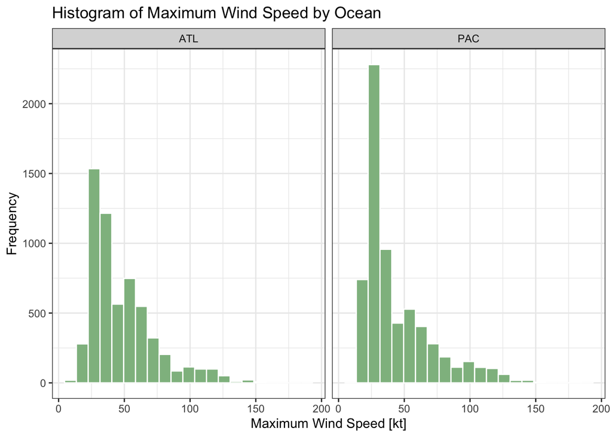

```r
# Histogram
ggplot(storms, aes(x = MaxWind)) +
  geom_histogram(binwidth = 9, fill = "darkseagreen", color = "white") +
  facet_wrap(~ocean) +
  labs(x = "Maximum Wind Speed [kt]",
       y = "Frequency",
       title = "Histogram of Maximum Wind Speed by Ocean") +
  theme_bw()
```

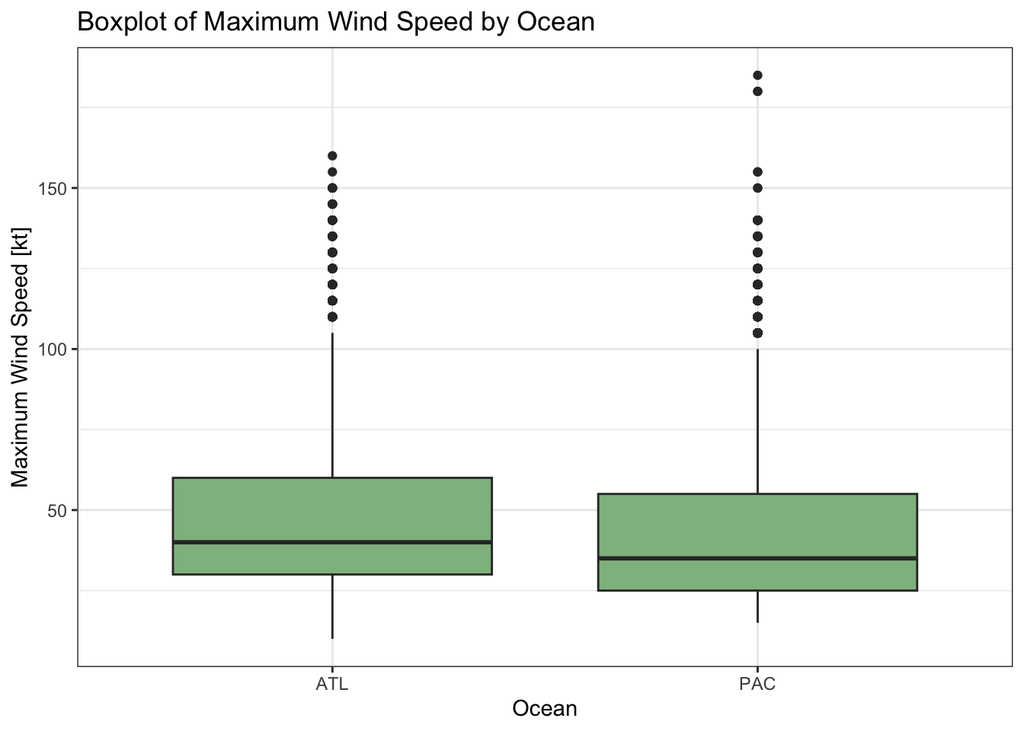

```r
# Box Plot
ggplot(storms, aes(x = ocean, y = MaxWind)) +
  geom_boxplot(fill = "darkseagreen") +
  labs(x = "Ocean",
       y = "Maximum Wind Speed [kt]",
       title = "Boxplot of Maximum Wind Speed by Ocean") +
  theme_bw()
```

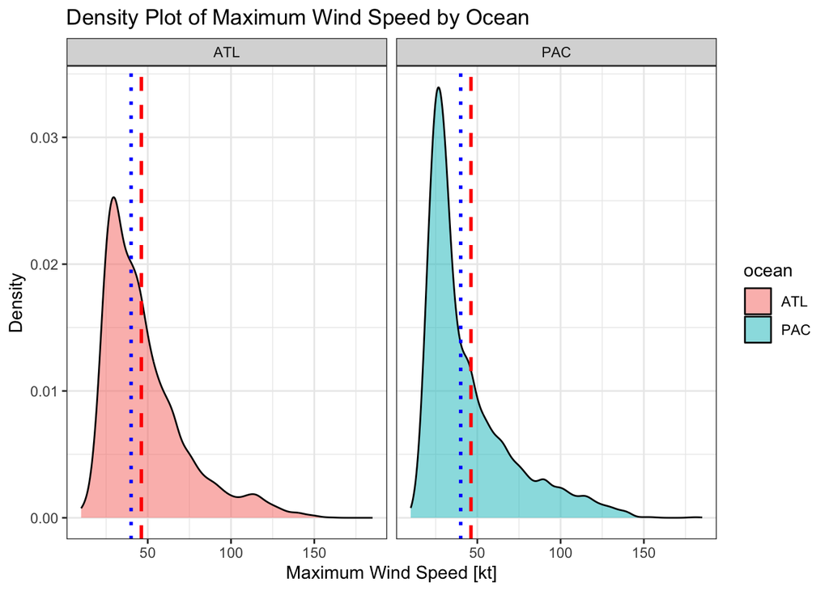

```r
# Density Plot
ggplot(storms, aes(x = MaxWind, fill = ocean)) +
  geom_density(alpha = 0.5) +
  geom_vline(xintercept = mean(storms$MaxWind),
             color = "red", linetype = "dashed", size = 1) +
    geom_vline(xintercept = median(storms$MaxWind),
             color = "blue", linetype = "dotted", size = 1) +
  facet_wrap(~ocean) +
  labs(title = "Density Plot of Maximum Wind Speed by Ocean",
       x = "Maximum Wind Speed [kt]",
       y = "Density") +
  theme_bw()
```

*Box Plot Interpretation*

The boxplots show that there are indeed outliers for both oceans in the upper range (faster wind speeds). The median for the Atlantic Ocean appears to be slightly greater than that of the Pacific, but the spread of both datasets is roughly the same.

*Density Plot Interpretation*

Similar to the histogram, the density plots show right skew for both the Atlantic and Pacific oceans. These distributions lack symmetry and therefore do not appear normal. The peak for the Pacific ocean is higher than that of the Atlantic, but both density curves appear to peak around the same value (~25 knots).

# Research Questions

## *1. Is there a relationship between wind speed and pressure for tropical storms?*

### Exploring Wind Speed - Pressure Relationship

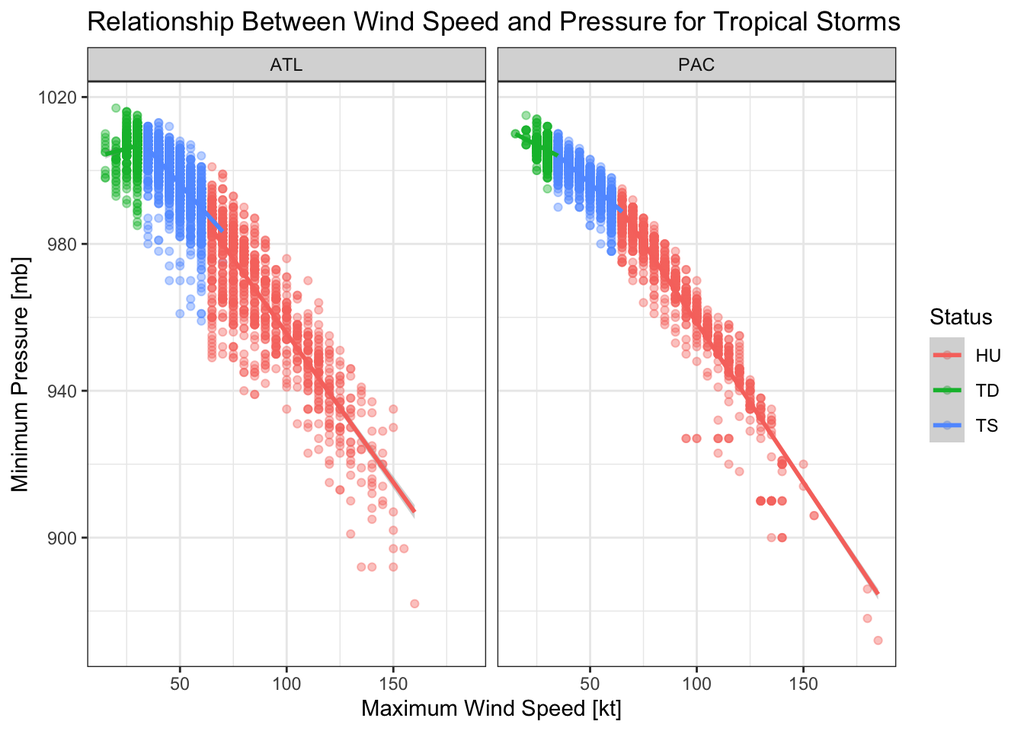

```r
# Select observations from tropical storm events
# Color by status (hurricane, storm, or depression)
storms %>% filter(status_group == "tropical") %>%
  ggplot(aes(x = MaxWind, y = MinPress, color = Status)) +
  geom_point(alpha = 0.4) + # Adjust opacity of points
  labs(x = "Maximum Wind Speed [kt]", # Wind Speeds measured in knots
       y = "Minimum Pressure [mb]", # Pressure measure in millibars
       title = "Relationship Between Wind Speed and Pressure for Tropical Storms") +
  # Add line using linear model method
  geom_smooth(method = "lm") +
  facet_wrap(~ocean) +
  theme_bw()
```

This plot graphs observations of minimum pressure against maximum wind speed for tropical storms in both the Atlantic and Pacific Oceans. There appears to be a negative relationship between minimum pressure and maximum wind speed, meaning the lower the pressure, the faster the wind speed. This trend is pretty equal across both oceans. This relationship makes sense, as wind typically travels from regions of high pressure to low pressure. Thus, the greater this gradient is, or more different the low versus high pressure systems are, the faster the wind. The points are colored by status, indicating that storms categorized as hurricanes have the fastest winds and lowest pressure. In contrast, tropical depressions have the mildest winds and highest pressure.

## *2. Are these storms more common in certain regions?*

### Exploring Storm Category and Wind Speed - Location Relationship

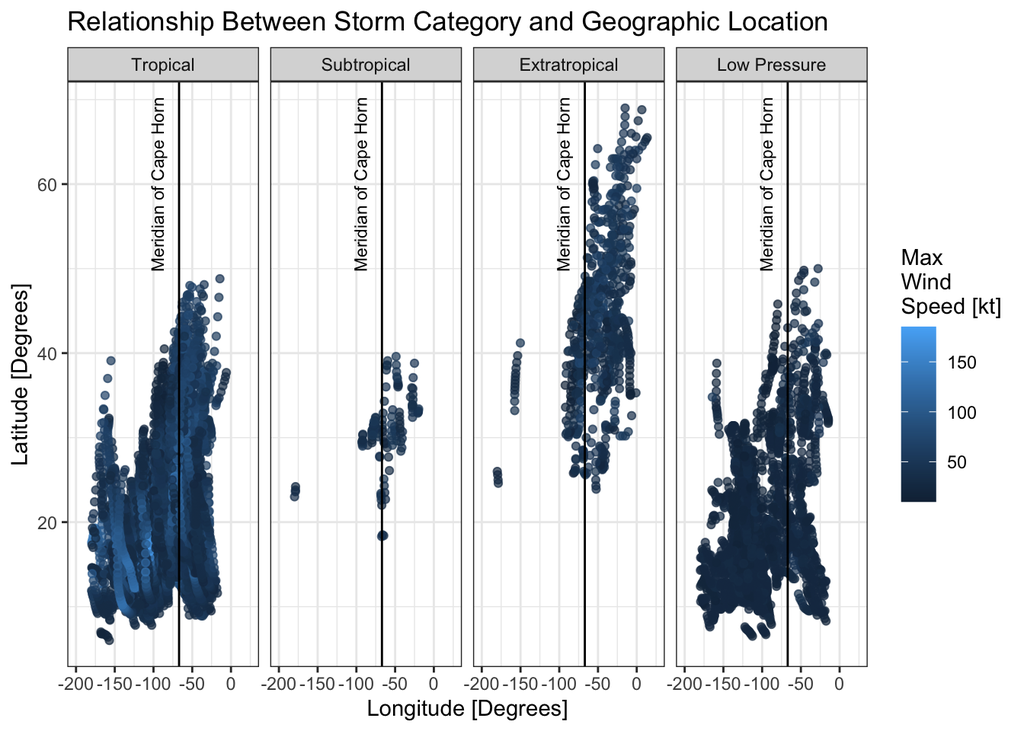

```r
# Removing any observations with a status that
# does not fit the main 4 categories (tropical, subtropical, etc.)
storms_filt <- storms %>%
  filter(status_group != "other")

# Plotting storms based on location and faceting by storm category
# Color represents maximum wind speeds
ggplot(storms_filt, aes(x = lon, y = lat, color = MaxWind)) +
  geom_point(alpha = 0.7) +
  facet_wrap(vars(status_group), nrow=1,
             labeller = as_labeller(c(tropical = "Tropical",
                                      subtropical = "Subtropical",
                                      extratropical = "Extratropical",
                                      `low-pressure` = "Low Pressure"))) +
  geom_vline(xintercept = -67) +
  annotate(
    "text",
    x = -80,
    y = 60,
    label = "Meridian of Cape Horn",
    angle = 90,
    vjust = -0.4,
    size = 3
  ) +
  coord_cartesian(xlim = c(-200, 25)) +
  labs(x = "Longitude [Degrees]",
       y = "Latitude [Degrees]",
       color = "Max\nWind\nSpeed [kt]",
       title = "Relationship Between Storm Category and Geographic Location") +
  theme_bw()
```

This plot shows the locations of storms of different categories (tropical, subtropical, extratropical, and low pressure). Extratropical storms seem to occur most commonly at higher latitudes (closer to the North Pole), while tropical storms and low pressure events occur more at lower latitudes (closer to the equator). The Meridian of Cape Horn line denotes the approximate separation between the Atlantic and Pacific Oceans. From the figure, we can see that extratropical storms mainly occur in the Atlantic, while tropical storms and low pressure systems mostly occur in the Pacific. The points are colored on a gradient by maximum wind speed (kt). We can see on the plot that low pressure systems have slower wind speeds compared to tropical storms, which have the fastest wind speeds.